# Notebook 4 Visualizing Trends (Teacher)

## Notebook 4: Visualizing Trends

In the previous notebook, we created histograms, bar charts, and boxplots. These visualizations helped us understand how numerical values are distributed as well as how they compare across groups.

In this notebook, we focus on line charts to explore how values change over time.

In this notebook, you will:

- Group and summarize data across time.
- Examine how values change over time.
- Create line charts to display trends.

### 1.0 - Python Libraries

```python
## Run this code but do not edit it. Hit Ctrl+Enter to run the code
# This command imports pandas library and creates an alias named pd
import pandas as pd

# This command imports the matplotlib.pyplot module and creates an alias named plt
import matplotlib.pyplot as plt
plt.rcParams["figure.figsize"]=(12, 6)
```

### 2.0 - Loading and Inspecting the Data

To begin, let's download our data. We'll download the `updated_gss.csv` from a URL and store it into a `pandas` `DataFrame` object called `gss`.

### The Dataset (`updated_gss.csv`)

**General description:** The [General Social Survey (GSS)](https://gss.norc.org/) is a nationally representative survey of adults in the United States that was started in 1972. Conducted by the non-partisan [National Opinion Research Center (NORC)](https://www.norc.org/), the GSS collects data on a wide variety of topics in contemporary American society, including civil liberties, crime, intergroup tolerance, and social mobility. Its core purpose is to monitor and explain trends in opinions, attitudes, and behaviors.

The dataset used in this notebook is a subset of the full GSS, containing selected variables and survey years chosen to support instructional exploration and analysis. t also includes a cleaned version of the `wwwhr` column, with text-based response codes removed, replaced by missing values (`NA`), and remaining values converted to numeric.

**Description of all variables:** See [here.](https://ds4e-org.github.io/ap-cs-dsc/var.html)

**Detailed data file description:** See [here.](https://docs.google.com/spreadsheets/d/1AC6ZEz_00ZjoBBWrBpAgnybOqzFOsKFX/edit?gid=61928758#gid=61928758)

```python
## Run this code but do not edit it. Hit Ctrl+Enter to run the code
# This command downloads the data and stores it in the object gss
base_url = "https://raw.githubusercontent.com/ds4e-org/ap-cs-dsc/refs/heads/main/data/"
filename = "updated_gss.csv"
url = base_url + filename

gss = pd.read_csv(url)
```

**2.1 -** Use the `.head()` method to print out the first several rows of the dataset.

```python
# Your code goes here
gss.head()
```

|  | id | birth_year | survey_year | age | age_group | sex | reg16 | region | born | parborn | ... | natenvir | happy | happy7 | hapunhap | goodlife | opclout | ophrdwrk | opknow | opwlth | opeduc |
| --- | --- | --- | --- | --- | --- | --- | --- | --- | --- | --- | --- | --- | --- | --- | --- | --- | --- | --- | --- | --- | --- |
| 0 | 1 | 1955 | 1987 | 32 | 26-35 (Early Career) | MALE | Northeast | Northeast | YES | Both born in the U.S. | ... | TOO LITTLE | Pretty happy | .i: Inapplicable | .i: Inapplicable | Disagree | Not very important | Fairly important | Not very important | Fairly important | Fairly important |
| 1 | 2 | 1950 | 1987 | 37 | 36-50 (Mid Career) | FEMALE | Midwest | Northeast | YES | Both born in the U.S. | ... | .i: Inapplicable | Pretty happy | .i: Inapplicable | .i: Inapplicable | Disagree | Not very important | Fairly important | Fairly important | Fairly important | Very important |
| 2 | 5 | 1957 | 1987 | 30 | 26-35 (Early Career) | MALE | Northeast | Northeast | YES | Both born in the U.S. | ... | .i: Inapplicable | Not too happy | .i: Inapplicable | .i: Inapplicable | Disagree | Very important | Essential | Very important | Essential | Very important |
| 3 | 6 | 1955 | 1987 | 32 | 26-35 (Early Career) | MALE | Northeast | Northeast | YES | Neither born in the U.S. | ... | TOO LITTLE | Pretty happy | .i: Inapplicable | .i: Inapplicable | Agree | Not very important | Very important | Fairly important | Fairly important | Fairly important |
| 4 | 7 | 1958 | 1987 | 29 | 26-35 (Early Career) | FEMALE | Northeast | Northeast | YES | Both born in the U.S. | ... | .i: Inapplicable | Not too happy | .i: Inapplicable | .i: Inapplicable | Agree | Very important | Essential | Fairly important | Essential | Essential |

5 rows × 45 columns

**2.2 -** Use the `.info()` method to print out information about the dataframe's structure.

```python
# Your code goes here
gss.info()
```

```
<class 'pandas.core.frame.DataFrame'>
RangeIndex: 21758 entries, 0 to 21757
Data columns (total 45 columns):
 #   Column       Non-Null Count  Dtype
---  ------       --------------  -----
 0   id           21758 non-null  int64
 1   birth_year   21758 non-null  int64
 2   survey_year  21758 non-null  int64
 3   age          21758 non-null  int64
 4   age_group    21758 non-null  object
 5   sex          21758 non-null  object
 6   reg16        21758 non-null  object
 7   region       21758 non-null  object
 8   born         21758 non-null  object
 9   parborn      21758 non-null  object
```

[output cut: 37 more lines]

An important component of exploratory data analysis (EDA) is asking questions about the data to guide which variables to examine and which patterns or changes to investigate. Because EDA is iterative, answering one question often raises new ones and prompts further exploration.

**2.3 -** Choose two variables that you think are likely to show meaningful change over time. For each variable, explain why you chose it and what type of change or pattern you expect to observe across survey years.  
**Note:** A description of all variables can be found [here](https://ds4e-org.github.io/ap-cs-dsc/var.html).

**Double-click to type a response:**

**Instructor Note:** Here are a few of our choices and reasoning for variables most likely to show meaningful change over time. Helping students develop their ability to select vatiables to explore will be helpful for the decisions they make later in the data analysis process.

- `wwwhr`: Internet access and technology have changed substantially over the years covered by the survey, so average hours spent online may increase over time as broadband and smartphones became more common.
- `hapunhap`: This variable reflects overall well-being, which may change as social and economic conditions change. Examining it over time can show whether reported happiness remains stable or shifts across survey years.
- `ophrdwrk`: Opinions about whether hard work leads to success may shift over time in response to economic conditions or changing social attitudes.
- `opwlth`: Views on wealth and inequality may change over time. This variable can show whether concern about wealth distribution increases in more recent years.

### 3.0 - Visualizing Trends Over Time

In this section, we visualize trends over time by examining how values change across survey years.

#### Line Charts

A common issue is creating a line chart without first organizing the data into the appropriate format. This can result in a cluttered or misleading plot because there are many observations for each survey year.

Below, we show what happens when `survey_year` and `wwwhr` values are plotted directly.

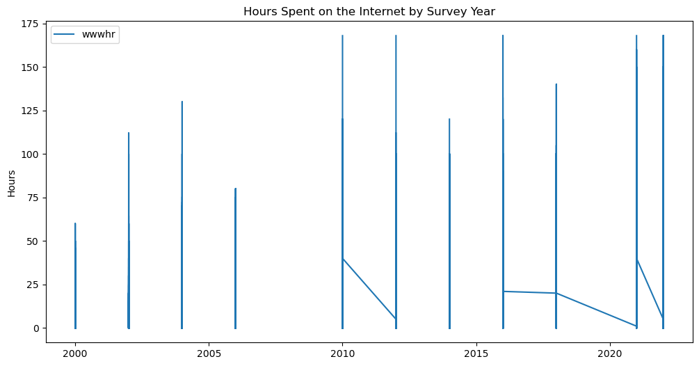

```python
## Run this code but do not edit it. Hit Ctrl+Enter to run the code
# Create a line chart for wwwhr for each survey_year
gss.plot(x="survey_year", y="wwwhr")
plt.xlabel("")
plt.ylabel("Hours")
plt.title("Hours Spent on the Internet by Survey Year")
plt.show();
```

**3.1 –** Use the sentence stems below to describe what you notice about the line chart and explain why it is difficult to interpret.

- The line chart appears cluttered because …
- Instead of showing a trend over time, the line …
- To create a more meaningful line chart, the data should first be …

**Double-click to type a response:**

**Instructor Note:** Here are some of our observations based on what we noticed. Helping students develop the habit of describing patterns and checking for unusual or unexpected results will support better decision-making later in the data analysis process.

- The line chart appears cluttered because the plot includes many individual observations for each survey year, causing overlapping points and sharp vertical changes.
- Instead of showing a trend over time, the line jumps between individual data points, making it difficult to see an overall pattern across years.
- To create a more meaningful line chart, the data should first be grouped by survey year and summarized (e.g., using a mean or median) so that each year is represented by a single value.

Line charts should be used with summarized values (for example, mean, median, proportion), not individual responses. In Java, creating these summaries would typically require writing loops to group records, keep running totals, and compute a final value for each year. In Pandas, the `.groupby()` method provides a more efficient way to group data by a variable like `survey_year` and calculate the summary statistic we want to use for plotting.

#### `.groupby()`

The `.groupby()` method in Pandas separates data into groups based on the values of one or more variables. Rows that share the same value for a grouping variable (for example as survey year) are placed into the same group. Within each group, we compute summary statistics (for example the mean) to produce a single value per group.

Here we display all the survey years in the dataset:

```python
## Run this code but do not edit it. Hit Ctrl+Enter to run the code
# Display the distinct survey years
gss["survey_year"].unique()
```

```
array([1987, 2000, 2002, 2004, 2006, 2008, 2010, 2012, 2014, 2016, 2018,
       2021, 2022, 2024])
```

Here, the `.groupby()` method is used to group the data by survey year. The result is stored in a variable named `grps_survey_year`.

```python
## Run this code but do not edit it. Hit Ctrl+Enter to run the code
# Group the data by survey year and store the result in grps_survey_year
grps_survey_year = gss.groupby("survey_year")
```

We can use the `.get_group()` method on the grouped data to retrieve the group for the survey year 2000 and display the first several rows:

```python
## Run this code but do not edit it. Hit Ctrl+Enter to run the code
# Get rows from the 2000 group
grps_survey_year.get_group(2000).head()
```

|  | id | birth_year | survey_year | age | age_group | sex | reg16 | region | born | parborn | ... | natenvir | happy | happy7 | hapunhap | goodlife | opclout | ophrdwrk | opknow | opwlth | opeduc |
| --- | --- | --- | --- | --- | --- | --- | --- | --- | --- | --- | --- | --- | --- | --- | --- | --- | --- | --- | --- | --- | --- |
| 1174 | 1 | 1974 | 2000 | 26 | 26-35 (Early Career) | MALE | South | South | YES | Both born in the U.S. | ... | TOO LITTLE | Pretty happy | .i: Inapplicable | .i: Inapplicable | .i: Inapplicable | .i: Inapplicable | .i: Inapplicable | .i: Inapplicable | .i: Inapplicable | .i: Inapplicable |
| 1175 | 2 | 1952 | 2000 | 48 | 36-50 (Mid Career) | FEMALE | Foreign | South | NO | Neither born in the U.S. | ... | .i: Inapplicable | Pretty happy | .i: Inapplicable | .i: Inapplicable | Agree | .i: Inapplicable | .i: Inapplicable | .i: Inapplicable | .i: Inapplicable | .i: Inapplicable |
| 1176 | 4 | 1961 | 2000 | 39 | 36-50 (Mid Career) | FEMALE | South | South | YES | Both born in the U.S. | ... | TOO LITTLE | Very happy | .i: Inapplicable | .i: Inapplicable | Agree | .i: Inapplicable | .i: Inapplicable | .n: No answer | .n: No answer | .i: Inapplicable |
| 1177 | 5 | 1975 | 2000 | 25 | 18-25 (Young Adult) | FEMALE | South | South | YES | Both born in the U.S. | ... | .i: Inapplicable | Pretty happy | .i: Inapplicable | .i: Inapplicable | Neither | .i: Inapplicable | .i: Inapplicable | Not very important | Not very important | .i: Inapplicable |
| 1178 | 6 | 1975 | 2000 | 25 | 18-25 (Young Adult) | FEMALE | South | South | YES | Mother no, father yes | ... | .i: Inapplicable | Pretty happy | .i: Inapplicable | .i: Inapplicable | Agree | .i: Inapplicable | .i: Inapplicable | Very important | Fairly important | .i: Inapplicable |

5 rows × 45 columns

From this group, we can access the `wwwhr` column to compute the average number of hours respondents reported using the internet.

```python
## Run this code but do not edit it. Hit Ctrl+Enter to run the code
# Calculate the mean from the 2000 group rounded to 2 decimal places
grps_survey_year.get_group(2000)["wwwhr"].mean().round(2)
```

```
np.float64(5.2)
```

**How this works:** The `.round(2)` method rounds the result to two decimal places.

**3.3 -** Calculate the mean of `wwwhr` for **2002**.

```python
# Your code goes here
grps_survey_year.get_group(2002)["wwwhr"].mean().round(2)
```

```
np.float64(6.32)
```

**Check yourself:** The mean should be 6.32.

**Double-click to type a response:**

**3.5 -** Using only the values you have examined so far (**2000** and **2002**), predict how the **average** value of `wwwhr` might change over time. Which year or time period between **2000** and **2024** do you expect to show the largest change? Explain your reasoning.

**Double-click to type a response:**

**Instructor Note:** This question is intentionally placed before students examine all years to encourage prediction based on limited information. Students will later revisit and verify their predictions using the full dataset. Emphasize that exploratory data analysis is not a single pass through a dataset; it is an iterative process of noticing patterns, forming tentative ideas, and then checking them against additional data. Making predictions based on limited information is part of this process.

Instead of focusing on a single year, we can perform the same calculation for all groups at once. Here, we calculate the mean of `wwwhr` for each survey year:

```python
## Run this code but do not edit it. Hit Ctrl+Enter to run the code
# Calculate the mean for each survey year
grps_survey_year["wwwhr"].mean().round(2)
```

```
survey_year
1987      NaN
2000     5.20
2002     6.32
2004     7.97
2006     9.68
2008      NaN
2010    10.97
2012    12.38
2014    13.69
2016    16.22
2018    17.09
2021    18.66
2022    19.51
2024      NaN
Name: wwwhr, dtype: float64
```

By adding the `.dropna()` method, we remove survey years where the question was not asked.

```python
## Run this code but do not edit it. Hit Ctrl+Enter to run the code
# Calculate the mean for each survey year and drop missing years
grps_survey_year["wwwhr"].mean().round(2).dropna()
```

```
survey_year
2000     5.20
2002     6.32
2004     7.97
2006     9.68
2010    10.97
2012    12.38
2014    13.69
2016    16.22
2018    17.09
2021    18.66
2022    19.51
Name: wwwhr, dtype: float64
```

Now that the data are organized by survey year with a corresponding mean for `wwwhr`, we can use this output with `.plot()` to create a line chart:

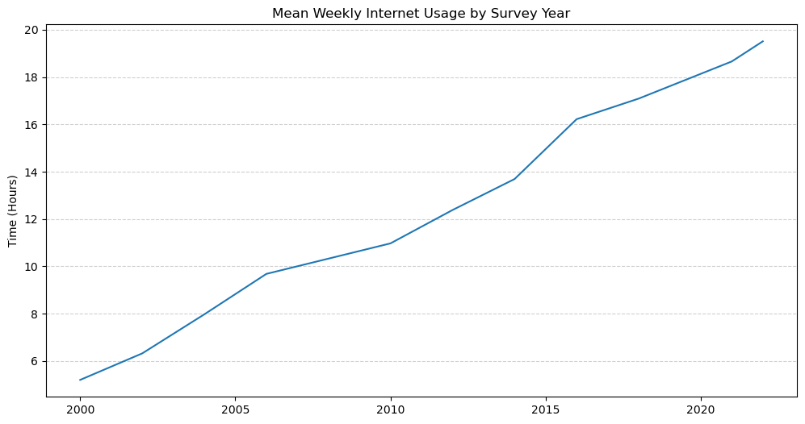

```python
## Run this code but do not edit it. Hit Ctrl+Enter to run the code
# Create the line chart
grps_survey_year["wwwhr"].mean().round(2).dropna().plot()

# Label the axes and the title
plt.xlabel("")
plt.ylabel("Time (Hours)")
plt.title("Mean Weekly Internet Usage by Survey Year")

# Add horizontal gridlines
plt.grid(axis="y", linestyle="--", alpha=0.6)
plt.show();
```

**How this works:** `plt.grid(axis="y", linestyle="--", alpha=0.6)` adds horizontal grid lines to the plot to support reading values along the $y$-axis.

- `axis="y"` specifies that grid lines should appear only for the $y$-axis.
- `linestyle="--"` uses dashed lines so the grid supports interpretation without overpowering the data.
- `alpha=0.6` reduces the opacity of the grid lines, keeping them subtle and visually unobtrusive.

**3.6 -** Describe the general trend shown in line chart.

**Double-click to type a response:**

Matplotlib’s flexibility allows for adjustments to visual elements of a plot or chart. In this case, $x$-axis tick marks are specified for the years, and markers are added to highlight individual data points along the line.

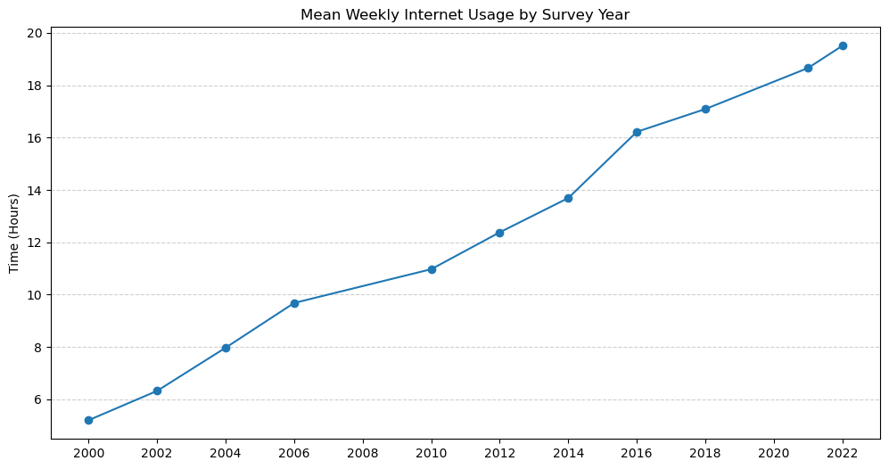

```python
## Run this code but do not edit it. Hit Ctrl+Enter to run the code
# Create evenly spaced tick marks every two years
wwwhr_years = range(2000, 2024, 2)

# Create the line chart with markers for survey years
grps_survey_year["wwwhr"].mean().round(2).dropna().plot(marker="o")

# Add x-axis tick marks for each year
plt.xticks(wwwhr_years)

# Label the axes and the title
plt.xlabel("")
plt.ylabel("Time (Hours)")
plt.title("Mean Weekly Internet Usage by Survey Year")

# Add horizontal gridlines
plt.grid(axis="y", linestyle="--", alpha=0.6)
plt.show();
```

**How this works:**

- `wwwhr_years = range(2000, 2024, 2)` creates a range object representing evenly spaced years from 2000 up to, but not including, 2024, increasing by 2 years at a time. This object defines a pattern for generating values rather than storing them explicitly. For students familiar with Java, this is similar to the counting logic in a for loop such as `for (int year = 2000; year < 2024; year += 2)`.
- `.plot(marker="o")` creates a line chart and adds circular markers to highlight each data point.
- `plt.xticks(wwwhr_years)` sets the tick marks on the $x$-axis using the values in `wwwhr_years`.

**3.7 -** Between which years does the increase appear to be the largest based on the chart? Explain your reasoning. Then briefly suggest one societal change that might help explain this increase.

**Double-click to type a response:**

**Instructor Note:** Here are our observations based on what we noticed. Helping students develop the habit of describing patterns and checking for unusual or unexpected results will support better decision-making later in the data analysis process.

- The increase appears to be largest between **2014** and **2016**.
- Societal changes during this period include:
  - Smartphones became widely used
  - Faster mobile networks
  - Social media and streaming services became part of daily routines

Using the same approach, we now examine years spent at a respondent’s current job to explore how employment patterns have changed over time. This may be especially interesting as you think about how the job market has evolved and what it could mean for life after high school.

**3.8 -** Using the `grps_survey_year` object, calculate the mean of the `yearsjob` variable (number of years respondents remained at their current job) for each survey year. Display only years with available data and round the results to two decimal places.

```python
# Your code goes here
grps_survey_year["yearsjob"].mean().round(2).dropna()
```

```
survey_year
2002    5.33
2006    5.34
2010    5.41
2014    5.50
2018    5.11
2022    4.85
Name: yearsjob, dtype: float64
```

**Check yourself:** Your code should have printed out:

```
    survey_year
    2002    5.33
    2006    5.34
    2010    5.41
    2014    5.50
    2018    5.11
    2022    4.85
```

**3.9 -** Create a line chart using the output from the previous code cell. Be sure to label the $y-$axis, include markers for each data point, and use evenly spaced tick marks on the $x-$axis.

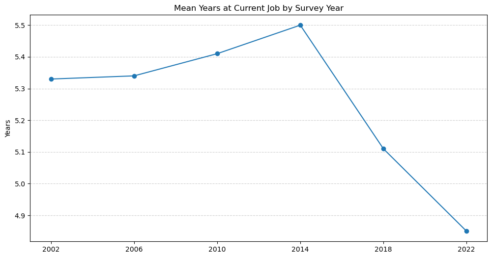

```python
# Your code goes here
yearsjob_years = range(2002, 2026, 4)
grps_survey_year["yearsjob"].mean().round(2).dropna().plot(marker="o")
plt.xticks(yearsjob_years)
plt.xlabel("")
plt.ylabel("Years")
plt.title("Mean Years at Current Job by Survey Year")
plt.grid(axis="y", linestyle="--", alpha=0.6)
plt.show();
```

**3.10 -** Describe the general trend shown in line chart.

**Double-click to type a response:**

**Instructor Note:** Here are our observations based on what we noticed. Helping students develop the habit of describing patterns and checking for unusual or unexpected results will support better decision-making later in the data analysis process.

The decrease between 2014 and 2022 appears large on the chart. In fact, from 2002 to 2014, the average number of years at the same job was increasing. This sharp shift beginning around 2014, followed by a steady decline through the most recent years of available data, raises a broader question: what might this change suggest about how behaviors are shifting over time.

**3.11 —** Consider the following broader question: *Why might people be staying at the same job for fewer years on average?* Discuss the questions below with a classmate or the instructor. You **do not** need to write anything.

- What factors might be contributing to this decrease in the average number of years at a job?
- What additional variables or data would help you better understand what is driving this trend?
- Why is it important to avoid making causal claims based on this analysis alone?

**Note:** There is no single correct answer to these questions. The goal is to practice thinking about multiple possible explanations for a pattern in the data.

**Instructor Note:** This discussion is designed to help students think about the broader question: *Why might people be staying at the same job for fewer years on average?* Encourage students to move beyond describing the pattern and begin considering multiple possible explanations, while remaining grounded in the data.

- This is part of exploratory data analysis, not a definitive conclusion. Emphasize that students are identifying patterns and associations, not causes. A decrease in average years at a job is consistent with more frequent job changes, but other factors could also contribute to this pattern.
- We cannot determine what caused this change from this analysis alone because:
  - The data are observational, not from a controlled experiment
  - Other variables that may influence job tenure are not accounted for
  - Multiple factors may be interacting at the same time
- Determining causality requires more advanced statistical methods and study designs (e.g., experiments or causal inference techniques), which go beyond the scope of this analysis. This is why we explore and analyze data—to identify patterns, ask better questions, and guide further investigation.
- Possible factors that could be associated with a decrease in average years at a current job include:
  - Changes in the age distribution of respondents (e.g., more younger workers)
  - Growth in temporary or contract-based work
  - Increased participation in part-time or gig employment
  - Shifts in when respondents enter or re-enter the workforce
- Reinforce that these are plausible explanations, not confirmed causes, and that additional data would be needed to evaluate them.

### 4.0 - Comparing Multiple Trends Over Time

In this section, we use multi-line charts to compare how values change over time across groups.

#### Multi-Line Charts (Numerical Data)

A multi-line chart is useful when we want to examine change over time for multiple groups simultaneously. Each line represents a different group, making it possible to compare patterns and trends across categories within the same chart.

The first step in creating a multi-line chart is to choose a categorical variable to define the groups being compared. In this case, the variable `age_group` is useful because it organizes ages into broad categories. Creating a separate line for each individual age, or for groups that are too granular, would result in a cluttered chart that is hard to read.

After selecting, we create a group object that includes both `age_group` and `survey_year`. Here, we create the group object `grps_age_groups`:

```python
## Run this code but do not edit it. Hit Ctrl+Enter to run the code
# Group the data by survey year and age group and store the result in grps_age_group
grps_age_groups = gss.groupby(["survey_year", "age_group"])
```

**Instructor Note (Code):**

- `gss.groupby(["survey_year", "age_group"])` groups the data simultaneously by survey year and age group. This creates groups for every unique combination of year and age group, allowing summary statistics (such as means or counts) to be computed separately for each group combination (e.g., 2002 for the age group 18-25 (Young Adult).
- Using multiple grouping variables in a single `.groupby()` operation is the standard approach when preparing data for multi-line charts, since it produces one summarized value per group per time point.

To verify the groups that were created, we can use the `.groups` attribute and its `.keys()` method to view the group labels.

```python
## Run this code but do not edit it. Hit Ctrl+Enter to run the code
# Display the unique combinations of survey_year and age_group
grps_age_groups.groups.keys()
```

```
dict_keys([(1987, '18-25 (Young Adult)'), (1987, '26-35 (Early Career)'), (1987, '36-50 (Mid Career)'), (2000, '18-25 (Young Adult)'), (2000, '26-35 (Early Career)'), (2000, '36-50 (Mid Career)'), (2002, '18-25 (Young Adult)'), (2002, '26-35 (Early Career)'), (2002, '36-50 (Mid Career)'), (2004, '18…
```

Here, we calculate the mean `yearsjob` for each age group and survey year:

```python
## Run this code but do not edit it. Hit Ctrl+Enter to run the code
# Calculate the mean years on the job for each age group and survey year
grps_age_groups["yearsjob"].mean().dropna().round(2)
```

```
survey_year  age_group
2002         18-25 (Young Adult)     1.57
             26-35 (Early Career)    3.63
             36-50 (Mid Career)      7.75
2006         18-25 (Young Adult)     1.34
             26-35 (Early Career)    3.50
             36-50 (Mid Career)      7.51
2010         18-25 (Young Adult)     2.08
             26-35 (Early Career)    3.35
             36-50 (Mid Career)      7.71
2014         18-25 (Young Adult)     1.29
             26-35 (Early Career)    3.78
             36-50 (Mid Career)      7.83
2018         18-25 (Young Adult)     1.56
             26-35 (Early Career)    3.38
             36-50 (Mid Career)      7.52
2022         18-25 (Young Adult)     1.39
             26-35 (Early Career)    3.32
             36-50 (Mid Career)      7.14
Name: yearsjob, dtype: float64
```

This output provides a value for each combination of survey year and age group. For example, in 2022, early-career adults ages 26–35 had, on average, spent a little over three years at their current job.

To prepare the data for a line chart, we restructure the grouped output so that each age group appears as a separate column. The `.unstack()` method moves the age group level into columns and aligns the values by survey year.

```python
## Run this code but do not edit it. Hit Ctrl+Enter to run the code
# Calculate the mean years on the job for each age group and survey year
# then reshape (unstack) so each age group is a column
grps_age_groups["yearsjob"].mean().dropna().round(2).unstack()
```

| age_group survey_year | 18-25 (Young Adult) | 26-35 (Early Career) | 36-50 (Mid Career) |
| --- | --- | --- | --- |
| 2002 | 1.57 | 3.63 | 7.75 |
| 2006 | 1.34 | 3.50 | 7.51 |
| 2010 | 2.08 | 3.35 | 7.71 |
| 2014 | 1.29 | 3.78 | 7.83 |
| 2018 | 1.56 | 3.38 | 7.52 |
| 2022 | 1.39 | 3.32 | 7.14 |

This output displays one column for each age group and one row for each survey year. Each value represents the average number of years respondents in that age group had spent at their current job during that survey year.

**How this works:**

- After grouping by survey year and age group, the results are organized using two levels of indexing. The `.unstack()` method moves one level of the index (here, `age_group`) into columns.
- This reshaping step prepares the data so that each age group appears as a separate line in the chart.

Now we can create a multi-line chart that shows one line for each age group across all survey years:

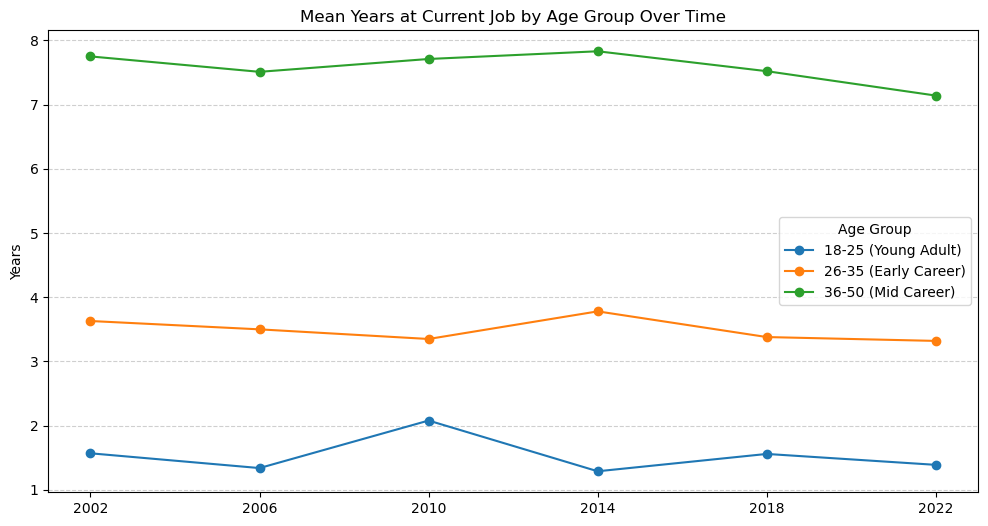

```python
## Run this code but do not edit it. Hit Ctrl+Enter to run the code
# Calculate the mean years on the job for each age group and survey year
# then reshape (unstack) so each age group is a column
# then create a line chart
grps_age_groups["yearsjob"].mean().dropna().round(2).unstack().plot(marker="o")

# Add x-axis tick marks for each year
plt.xticks(yearsjob_years)

# Label the axes and titles for plot and legend
plt.xlabel("")
plt.ylabel("Years")
plt.title("Mean Years at Current Job by Age Group Over Time")
plt.legend(title="Age Group")

# Add horizontal gridlines
plt.grid(axis="y", linestyle="--", alpha=0.6)
plt.show();
```

**How this works:**

- `plt.legend(title="Age Group")` customizes the title of the legend to *Age Group*.
- The legend shows which line corresponds to each age group.
- Legends are important in multi-line charts so viewers can interpret and compare the lines correctly.

**4.1 -** Describe the general trends shown in the multi-line chart, noting similarities and differences across the groups.

**Double-click to type a response:**

**Instructor Note:** Here are our observations based on what we noticed. Helping students develop the habit of describing patterns and checking for unusual or unexpected results will support better decision-making later in the data analysis process.

- Mid-career adults (36–50) consistently have the highest average years at their current job, remaining fairly stable with a slight decline by 2022.
- Early career adults (26–35) show moderate tenure, fluctuating around 3–4 years with a small peak around 2014.
- Young adults (18–25) have the lowest job tenure, generally around 1–2 years, with more variability but consistently below the other groups.
- Overall, job tenure increases with age, and these differences persist across survey years.

**4.2 -** Use `grps_age_groups` to calculate the mean number of hours respondents reported spending on the internet (`wwwhr`) for each survey year. Display only years with data and round the results to two decimal places.

```python
# Your code goes here
grps_age_groups["wwwhr"].mean().dropna().round(2)
```

```
survey_year  age_group
2000         18-25 (Young Adult)      5.69
             26-35 (Early Career)     4.97
             36-50 (Mid Career)       5.19
2002         18-25 (Young Adult)      6.69
             26-35 (Early Career)     5.88
             36-50 (Mid Career)       6.48
2004         18-25 (Young Adult)      8.71
             26-35 (Early Career)     7.98
             36-50 (Mid Career)       7.65
2006         18-25 (Young Adult)      8.85
             26-35 (Early Career)    10.85
             36-50 (Mid Career)       9.26
2010         18-25 (Young Adult)     13.02
             26-35 (Early Career)    11.81
             36-50 (Mid Career)       9.36
2012         18-25 (Young Adult)     13.74
             26-35 (Early Career)    13.36
             36-50 (Mid Career)      11.01
2014         18-25 (Young Adult)     15.54
             26-35 (Early Career)    15.76
             36-50 (Mid Career)      11.47
2016         18-25 (Young Adult)     18.02
             26-35 (Early Career)    18.87
             36-50 (Mid Career)      13.15
2018         18-25 (Young Adult)     20.52
             26-35 (Early Career)    20.26
             36-50 (Mid Career)      13.48
2021         18-25 (Young Adult)     22.17
             26-35 (Early Career)    21.29
             36-50 (Mid Career)      16.31
2022         18-25 (Young Adult)     23.90
             26-35 (Early Career)    20.90
             36-50 (Mid Career)      16.76
Name: wwwhr, dtype: float64
```

**Check yourself:** The output should be:

```
             survey_year  age_group
    2000     18-25 (Young Adult)      5.69
             26-35 (Early Career)     4.97
             36-50 (Mid Career)       5.19
    2002     18-25 (Young Adult)      6.69
             26-35 (Early Career)     5.88
             36-50 (Mid Career)       6.48
    2004     18-25 (Young Adult)      8.71
             26-35 (Early Career)     7.98
             36-50 (Mid Career)       7.65
    2006     18-25 (Young Adult)      8.85
             26-35 (Early Career)    10.85
             36-50 (Mid Career)       9.26
    2010     18-25 (Young Adult)     13.02
             26-35 (Early Career)    11.81
             36-50 (Mid Career)       9.36
    2012     18-25 (Young Adult)     13.74
             26-35 (Early Career)    13.36
             36-50 (Mid Career)      11.01
    2014     18-25 (Young Adult)     15.54
             26-35 (Early Career)    15.76
             36-50 (Mid Career)      11.47
    2016     18-25 (Young Adult)     18.02
             26-35 (Early Career)    18.87
             36-50 (Mid Career)      13.15
    2018     18-25 (Young Adult)     20.52
             26-35 (Early Career)    20.26
             36-50 (Mid Career)      13.48
    2021     18-25 (Young Adult)     22.17
             26-35 (Early Career)    21.29
             36-50 (Mid Career)      16.31
    2022     18-25 (Young Adult)     23.90
             26-35 (Early Career)    20.90
             36-50 (Mid Career)      16.76
```

**4.3 -** Use `grps_age_groups` to calculate the mean of `wwwhr` for each survey year. Then restructure the result so that each age group appears as a separate column. Display only years with data and round the results to two decimal places.

```python
# Your code goes here
grps_age_groups["wwwhr"].mean().round(2).dropna().unstack()
```

| age_group survey_year | 18-25 (Young Adult) | 26-35 (Early Career) | 36-50 (Mid Career) |
| --- | --- | --- | --- |
| 2000 | 5.69 | 4.97 | 5.19 |
| 2002 | 6.69 | 5.88 | 6.48 |
| 2004 | 8.71 | 7.98 | 7.65 |
| 2006 | 8.85 | 10.85 | 9.26 |
| 2010 | 13.02 | 11.81 | 9.36 |
| 2012 | 13.74 | 13.36 | 11.01 |
| 2014 | 15.54 | 15.76 | 11.47 |
| 2016 | 18.02 | 18.87 | 13.15 |
| 2018 | 20.52 | 20.26 | 13.48 |
| 2021 | 22.17 | 21.29 | 16.31 |
| 2022 | 23.90 | 20.90 | 16.76 |

**Check yourself:** For 2000, 2012, and 2021, the output should be:

| survey_year | 18-25 (Young Adult) | 26-35 (Early Career) | 36-50 (Mid Career) |
| --- | --- | --- | --- |
| 2000 | 5.69 | 4.97 | 5.19 |
| 2012 | 13.74 | 13.36 | 11.01 |
| 2021 | 22.17 | 21.29 | 16.31 |

**4.4 -** Create a multi-line chart showing the mean number of hours spent using the internet for each age group across all survey years.  
To improve readability and interpretation:

- Use `wwwhr_years` to specify the tick marks on the $x$-axis
- Add markers so each data point for a survey year is visible
- Label the legend so it is clear which line corresponds to each age group

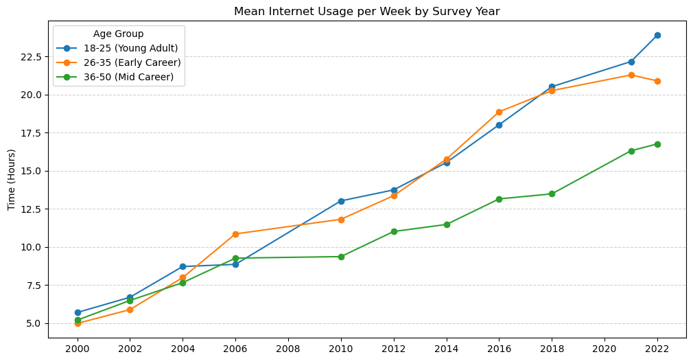

```python
# Your code goes here
grps_age_groups["wwwhr"].mean().round(2).dropna().unstack().plot(marker="o")
plt.xticks(wwwhr_years)
plt.xlabel("")
plt.ylabel("Time (Hours)")
plt.title("Mean Internet Usage per Week by Survey Year")
plt.legend(title="Age Group")
plt.grid(axis="y", linestyle="--", alpha=0.6)
plt.show();
```

**4.5 -** Describe the general trends shown in the multi-line chart, noting similarities and differences across the groups.

**Double-click to type a response:**

#### Multi-Line Charts (Categorical Data)

So far, we have used multi-line charts to compare trends in numerical values across groups. We can extend this idea to categorical data by summarizing responses within each group. Instead of plotting averages, we calculate proportions and use a multi-line chart to show how these proportions change over time.

We will follow a similar process as before, but the way we aggregate the data will be different. First, we select a categorical variable to explore. Then, we group the data by survey year, reshape the result so that each category appears as a separate column, and create a multi-line chart.

For this example, we use `hsmath`, which records the highest level of math completed by each respondent in high school.

First, we examine how many response categories are present to determine how to structure the analysis.

```python
## Run this code but do not edit it. Hit Ctrl+Enter to run the code
# Display the response categories for hsmath
gss["hsmath"].value_counts()
```

```
hsmath
.i:  Inapplicable                             13618
.y:  Not available in this year                3376
Two years of algebra                            866
Geometry (plane or solid or both)               711
Calculus                                        609
One year of algebra                             575
Trigonometry/linear programming/analysis        517
General math, business, or vocational math      453
Pre-calculus                                    426
Pre-algebra                                     192
.d:  Do not Know/Cannot Choose                  145
Statistics/probability                          134
No math in hs; didn't go to hs                   53
.n:  No answer                                   48
Other                                            35
Name: count, dtype: int64
```

From the output, we can see that there are many response categories, including non-substantive responses. To focus on meaningful course data, we remove these categories before grouping the data by `survey_year` and `hsmath`, and save the result to `gss_math`.

```python
## Run this code but do not edit it. Hit Ctrl+Enter to run the code
# Create a list of non-substantive categories
non_sub_math = [
    ".d:  Do not Know/Cannot Choose",
    ".i:  Inapplicable",
    ".n:  No answer",
    ".y:  Not available in this year",
    "No math in hs; didn't go to hs"
]

# Create a mask of non-substantive categories
non_sub_math_mask = gss["hsmath"].isin(non_sub_math)

# Filter the dataset to keep only rows with substantive course responses
# The ~ operator reverses the mask to keep rows that are NOT in the non-substantive list
gss_math = gss[~non_sub_math_mask].copy()

# Display the counts of the remaining hsmath categories
gss_math["hsmath"].value_counts()
```

```
hsmath
Two years of algebra                          866
Geometry (plane or solid or both)             711
Calculus                                      609
One year of algebra                           575
Trigonometry/linear programming/analysis      517
General math, business, or vocational math    453
Pre-calculus                                  426
Pre-algebra                                   192
Statistics/probability                        134
Other                                          35
Name: count, dtype: int64
```

**How this works:** The `~` operator reverses a condition. In this case, `non_sub_math_mask` identifies rows with non-substantive responses. Using `~non_sub_math_mask` keeps all rows that are **not** in that list.

In other words, `gss[~non_sub_math_mask]` filters the dataset to include only rows with valid (substantive) course responses.

After removing non-substantive categories, we can now group the data by `survey_year` and `hsmath`.

```python
## Run this code but do not edit it. Hit Ctrl+Enter to run the code
# Group the data by survey year and hsmath, and store the result in grps_math
grps_math = gss_math.groupby(["survey_year", "hsmath"])

# Display the unique combinations of survey_year and hsmath
grps_math.groups.keys()
```

```
dict_keys([(2006, 'Calculus'), (2006, 'General math, business, or vocational math'), (2006, 'Geometry (plane or solid or both)'), (2006, 'One year of algebra'), (2006, 'Other'), (2006, 'Pre-algebra'), (2006, 'Pre-calculus'), (2006, 'Statistics/probability'), (2006, 'Trigonometry/linear programming/a…
```

There are several response categories we could explore. After grouping the data by `survey_year` and `hsmath`, we see the unique combinations of these variables. To understand how responses are distributed over time, we count the number of respondents in each category for each year and store the result in a table named `math_counts`.

```python
## Run this code but do not edit it. Hit Ctrl+Enter to run the code
# Count the number of respondents in each year and course, then group and reshape into a table
math_counts = grps_math.size().unstack()

# Display the counts
math_counts
```

| hsmath survey_year | Calculus | General math, business, or vocational math | Geometry (plane or solid or both) | One year of algebra | Other | Pre-algebra | Pre-calculus | Statistics/probability | Trigonometry/linear programming/analysis | Two years of algebra |
| --- | --- | --- | --- | --- | --- | --- | --- | --- | --- | --- |
| 2006 | 131.0 | 119.0 | 199.0 | 146.0 | 10.0 | 58.0 | 82.0 | 21.0 | 122.0 | 188.0 |
| 2008 | 83.0 | 118.0 | 121.0 | 109.0 | 8.0 | 33.0 | 75.0 | 17.0 | 106.0 | 140.0 |
| 2010 | 54.0 | 30.0 | 50.0 | 36.0 | 7.0 | 12.0 | 32.0 | 13.0 | 54.0 | 73.0 |
| 2012 | 79.0 | 42.0 | 69.0 | 49.0 | NaN | 14.0 | 53.0 | 21.0 | 43.0 | 85.0 |
| 2014 | 84.0 | 55.0 | 90.0 | 74.0 | NaN | 27.0 | 50.0 | 14.0 | 68.0 | 133.0 |
| 2016 | 92.0 | 50.0 | 112.0 | 71.0 | 7.0 | 29.0 | 68.0 | 24.0 | 65.0 | 130.0 |
| 2018 | 86.0 | 39.0 | 70.0 | 90.0 | 3.0 | 19.0 | 66.0 | 24.0 | 59.0 | 117.0 |

**How this works:**

- After grouping by survey year and category, the `.size()` method counts the number of respondents in each group.
- This produces the frequency of responses for each category within each year, which forms the basis for calculating proportions.

The table shows the number of respondents in each category for each year. To compare across categories and years, we convert these counts to proportions by dividing each value by the total number of respondents in that year who provided a valid response.

Here, we use the `.div()` method to perform this calculation across each row of the table.

```python
## Run this code but do not edit it. Hit Ctrl+Enter to run the code
# Convert math_counts to proportions so each value represents the share of respondents in that year
math_proportions = math_counts.div(math_counts.sum(axis=1), axis=0)

# Display the proportions
math_proportions
```

| hsmath survey_year | Calculus | General math, business, or vocational math | Geometry (plane or solid or both) | One year of algebra | Other | Pre-algebra | Pre-calculus | Statistics/probability | Trigonometry/linear programming/analysis | Two years of algebra |
| --- | --- | --- | --- | --- | --- | --- | --- | --- | --- | --- |
| 2006 | 0.121747 | 0.110595 | 0.184944 | 0.135688 | 0.009294 | 0.053903 | 0.076208 | 0.019517 | 0.113383 | 0.174721 |
| 2008 | 0.102469 | 0.145679 | 0.149383 | 0.134568 | 0.009877 | 0.040741 | 0.092593 | 0.020988 | 0.130864 | 0.172840 |
| 2010 | 0.149584 | 0.083102 | 0.138504 | 0.099723 | 0.019391 | 0.033241 | 0.088643 | 0.036011 | 0.149584 | 0.202216 |
| 2012 | 0.173626 | 0.092308 | 0.151648 | 0.107692 | NaN | 0.030769 | 0.116484 | 0.046154 | 0.094505 | 0.186813 |
| 2014 | 0.141176 | 0.092437 | 0.151261 | 0.124370 | NaN | 0.045378 | 0.084034 | 0.023529 | 0.114286 | 0.223529 |
| 2016 | 0.141975 | 0.077160 | 0.172840 | 0.109568 | 0.010802 | 0.044753 | 0.104938 | 0.037037 | 0.100309 | 0.200617 |
| 2018 | 0.150087 | 0.068063 | 0.122164 | 0.157068 | 0.005236 | 0.033159 | 0.115183 | 0.041885 | 0.102967 | 0.204188 |

**How this works:**

- `counts.sum(axis=1)` computes the total number of respondents for each survey year (row total).
- `.div(counts.sum(axis=1), axis=0)` method divides each value in a row by that row’s total. The `axis=0` argument applies the division row by row.

This table shows the proportion of respondents in each course by year. Because non-substantive categories were removed, these proportions are based only on respondents who reported a valid math course. For example, in 2006, 0.121747 (12.1%) of respondents reported Calculus as the highest level completed, decreasing to 0.102469 (10.2%) in 2008. Overall, the proportion increases to a peak in 2012 before decreasing and then slightly increasing again by 2018.

Plotting all of them would make the chart cluttered and difficult to interpret. To keep the visualization clear, we will select three categories: `Statistics/probability`, `Pre-calculus`, and `Calculus`.

**4.6 -** Create a list named `math_courses` and store the following course names as strings: **Calculus**, **Pre-calculus**, and **Statistics/probability**.

```python
# Your code goes here
math_courses = ["Calculus", "Pre-calculus", "Statistics/probability"]

# Display the items in the math_courses list
math_courses
```

```
['Calculus', 'Pre-calculus', 'Statistics/probability']
```

**Check yourself:** Confirm that your list has 3 elements - `Calculus`, `Pre-calculus`, and `Statistics/probability` .

Now filter the data to focus on the math courses we want to examine.

```python
## Run this code but do not edit it. Hit Ctrl+Enter to run the code
# Display the table for the specified math courses
math_proportions[math_courses]
```

| hsmath survey_year | Calculus | Pre-calculus | Statistics/probability |
| --- | --- | --- | --- |
| 2006 | 0.121747 | 0.076208 | 0.019517 |
| 2008 | 0.102469 | 0.092593 | 0.020988 |
| 2010 | 0.149584 | 0.088643 | 0.036011 |
| 2012 | 0.173626 | 0.116484 | 0.046154 |
| 2014 | 0.141176 | 0.084034 | 0.023529 |
| 2016 | 0.141975 | 0.104938 | 0.037037 |
| 2018 | 0.150087 | 0.115183 | 0.041885 |

Here, we create the multi-line chart:

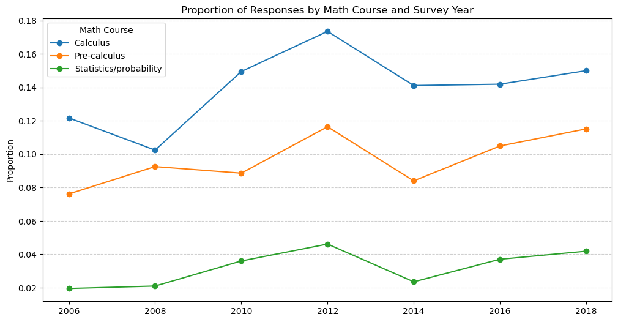

```python
## Run this code but do not edit it. Hit Ctrl+Enter to run the code
# Filter the proportions table for the specified math courses
# Drop the
math_proportions[math_courses].dropna().plot(marker="o")

# Label the axes and titles for plot and legend
plt.xlabel("")
plt.ylabel("Proportion")
plt.title("Proportion of Responses by Math Course and Survey Year")
plt.legend(title="Math Course")

# Add horizontal gridlines
plt.grid(axis="y", linestyle="--", alpha=0.6)
plt.show();
```

**4.7 -** Describe the general trends shown in the multi-line chart, noting similarities and differences across the courses.

**Double-click to type a response:**

**Instructor Note:** Here’s our observations for what we noticed. Helping students develop the habit of verifying the output of their code and checking for unusual or unexpected results will support better decision-making later in the data analysis process.

Emphasize that these values represent the proportion of respondents reporting each course, not actual enrollment rates. Encourage students to describe patterns they observe and consider possible explanations, while avoiding causal claims based on this visualization alone.

The process used to create this line chart can be applied to explore other variables over time, compare groups, or examine how survey responses change across years. For example, you might use the same approach to investigate trends in science courses such as physics or chemistry. Here, we examine the distribution of responses to the question:

> Did you take a physics course in high school?

```python
## Run this code but do not edit it. Hit Ctrl+Enter to run the code
# Display the response categories for hsphys
gss["hsphys"].value_counts()
```

```
hsphys
.i:  Inapplicable                  13618
.y:  Not available in this year     3376
No                                  2942
Yes                                 1733
.n:  No answer                        52
.d:  Do not Know/Cannot Choose        37
Name: count, dtype: int64
```

**4.8 –** Create a list named `sub_physics` that includes the substantive categories **"No"** and **"Yes"**.

```python
# Your code goes here
sub_physics = ["No", "Yes"]

# Display the items in the substantive_physcis list
sub_physics
```

```
['No', 'Yes']
```

**Check yourself:** Confirm that your list has 2 elements - `No` and `Yes` .

**Instructor Note:** In this situation it is better to create the list containing the substantive categories "No" and "Yes" rather than listing all non-substantive responses because:

- It is shorter and easier to work with
- It reduces the amount of text students need to read and write
- It minimizes the chance of errors when typing long category names

**4.9 –** Filter the `gss` DataFrame to include only rows where respondents provided a "No" or "Yes" response for `hsphys`, and save the result to `gss_physics`.

```python
# Your code goes here
sub_physics_mask = gss["hsphys"].isin(sub_physics)
gss_physics = gss[sub_physics_mask].copy()

gss_physics["hsphys"].value_counts()
```

```
hsphys
No     2942
Yes    1733
Name: count, dtype: int64
```

**Check your work:** Confirm that your results include two categories: `No` (2942) and `Yes` (1733).

**4.10 –** Use the `gss_physics` dataframe and `.groupby` to group the data by `survey_year` and `hsphys`. Save the result to `grps_physics`.

```python
# Your code goes here
grps_physics = gss_physics.groupby(["survey_year", "hsphys"])
```

```python
## Run this code but do not edit it. Hit Ctrl+Enter to run the code
# Display the keys for the years 2008 and 2018
print(list(grps_physics.groups.keys()))
```

```
[(2006, 'No'), (2006, 'Yes'), (2008, 'No'), (2008, 'Yes'), (2010, 'No'), (2010, 'Yes'), (2012, 'No'), (2012, 'Yes'), (2014, 'No'), (2014, 'Yes'), (2016, 'No'), (2016, 'Yes'), (2018, 'No'), (2018, 'Yes')]
```

**Check yourself:** Confirm that output from the previous cell is: `[(2006, 'No'), (2006, 'Yes'), (2008, 'No'), (2008, 'Yes'), (2010, 'No'), (2010, 'Yes'), (2012, 'No'), (2012, 'Yes'), (2014, 'No'), (2014, 'Yes'), (2016, 'No'), (2016, 'Yes'), (2018, 'No'), (2018, 'Yes')]`

**4.11 -** Use `grps_physics` to create a table that displays the frequency of responses for each response category by survey year. Save the result in a table named `physics_counts`. Then display the table.

```python
# Your code goes here
physics_counts = grps_physics.size().unstack()

# Display the counts
physics_counts
```

| hsphys survey_year | No | Yes |
| --- | --- | --- |
| 2006 | 709 | 377 |
| 2008 | 550 | 290 |
| 2010 | 242 | 132 |
| 2012 | 283 | 188 |
| 2014 | 390 | 238 |
| 2016 | 413 | 258 |
| 2018 | 355 | 250 |

**Check your work:** Confirm that the output for each year matches the values below.

[output not shown]

**4.12 -** Create a table that displays the proportion of responses for each response category by survey year. Save the result in a table named `physics_proportions`. Then display the table.

```python
# Your code goes here
physics_proportions = physics_counts.div(physics_counts.sum(axis=1), axis=0)

# Display the proportions
physics_proportions
```

| hsphys survey_year | No | Yes |
| --- | --- | --- |
| 2006 | 0.652855 | 0.347145 |
| 2008 | 0.654762 | 0.345238 |
| 2010 | 0.647059 | 0.352941 |
| 2012 | 0.600849 | 0.399151 |
| 2014 | 0.621019 | 0.378981 |
| 2016 | 0.615499 | 0.384501 |
| 2018 | 0.586777 | 0.413223 |

**Check your work:** Confirm that the output for each year matches the values below.

| survey_year | No | Yes |
| --- | --- | --- |
| 2006 | 0.652855 | 0.347145 |
| 2008 | 0.654762 | 0.345238 |
| 2010 | 0.647059 | 0.352941 |
| 2012 | 0.600849 | 0.399151 |
| 2014 | 0.621019 | 0.378981 |
| 2016 | 0.615499 | 0.384501 |
| 2018 | 0.586777 | 0.413223 |

**4.13 -** Create a multi-line chart showing how the proportions of the **Yes** and **No** responses change over survey years.

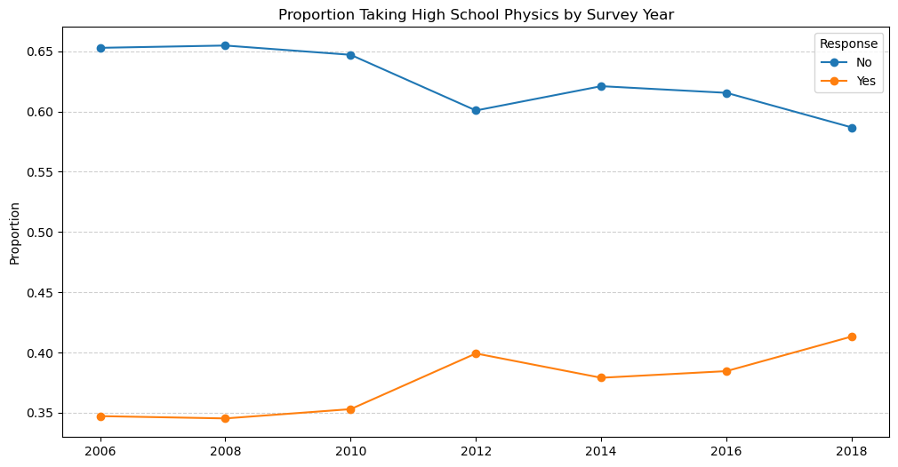

```python
# Ypur code goes here
physics_proportions.plot(marker="o")
plt.xlabel("")
plt.ylabel("Proportion")
plt.title("Proportion Taking High School Physics by Survey Year")
plt.legend(title="Response")
plt.grid(axis="y", linestyle="--", alpha=0.6)
plt.show();
```

**4.14 -** What is one pattern you notice, and what is one question you have about this trend? What is a possible explanation for your question? Discuss your ideas with a classmate. You do not need to write anything.

**Instructor Note:** Here are some observations based on the graph. Encouraging students to verify their results and look for patterns supports stronger data analysis habits.

- The proportion of respondents who report **not** taking physics is consistently higher than those who report **taking** physics across all years.
- From 2006 to 2010, the proportions remain relatively stable, with only small changes.
- There is a noticeable shift in 2012, where the proportion taking physics increases and the proportion not taking physics decreases.
- After 2012, the proportion of respondents reporting they took physics generally increases over time.
- At the same time, the proportion reporting they did not take physics shows a gradual decline overall, despite some fluctuations.

**Examples of questions students might consider:**

- Is this pattern consistent across other subjects or groups?
- Could changes in the survey or population affect these results?

The process used to create this line chart can be applied to explore other variables over time, compare groups, or examine how survey responses change across years. In the final notebook, you will have the opportunity to select variables of interest and apply these methods independently.

### 5.0 - Notebook Summary

In this notebook, we used visualizations to explore and compare patterns in data by:

- examining how values change over time, and
- comparing trends across different groups.

In data analysis, creating visualizations is also a form of data moves. Visual data moves involve transforming data into graphical representations to support interpretation, comparison, and questioning. Here, we focused on using line-based visualizations to explore change over time and differences across groups.

- Line charts show how a variable changes across an ordered variable, such as time.
- Multi-line charts allow us to compare how those changes differ across multiple groups within the same plot.

The visualizations created in this notebook demonstrate how line charts and multi-line charts support different data moves, helping us identify trends, compare groups, and generate new questions that may not be clear from tables or summary statistics alone.